# Segmentation Project for Design of Social Entertainment App

Elaine Evangelista

2022-06-17

### load packages

```r
library(dplyr)
library(readr)
library(tidyverse)
library(DataExplorer)
library(mice) #for imputation
library(cluster)
library(factoextra)
```

```r
library(purrr) #for the elbow plot
library(FactoMineR)
```

### Project Objective

The goal of the segmentation project is to determine optimal customers and their preferences for a company who wishes to build a “social entertainment app.” The customer preference data was taken from a survey of 1800 respondents.

The analysis uses kmeans clustering to group customers into clusters based on their responses to the survey questions.

##### Ingest the data

```
##      caseID q1 q2r1 q2r2 q2r3 q2r4 q2r5 q2r6 q2r7 q2r8 q2r9 q2r10 q4r1 q4r2
## 1853   1853  2    0    0    1    0    0    0    0    0    0     0    1    0
## 1097   1097  2    0    1    0    0    0    0    0    0    0     0    0    0
## 65       65  6    0    0    1    0    0    0    0    0    0     0    0    0
## 1762   1762  2    0    0    1    0    0    0    0    0    0     0    1    0
## 1016   1016  4    1    1    0    1    0    0    0    1    0     0    1    1
## 1511   1511  1    1    1    0    0    0    0    0    1    0     0    1    0
##      q4r3 q4r4 q4r5 q4r6 q4r7 q4r8 q4r9 q4r10 q4r11 q5r1 q11 q12 q13r1 q13r2
## 1853    0    0    0    1    0    0    0     0     0    1   4   5     1     1
## 1097    0    0    1    1    0    1    0     0     0   NA   3   5     1     4
## 65      0    0    0    1    1    1    0     0     0   NA   3   6     1     4
## 1762    0    0    1    1    0    0    0     0     0    1   4   4     4     4
## 1016    0    1    1    1    1    1    0     0     0    0   3   6     1     3
## 1511    1    0    1    0    0    1    0     0     0    0   4   3     4     4
##      q13r3 q13r4 q13r5 q13r6 q13r7 q13r8 q13r9 q13r10 q13r11 q13r12 q24r1 q24r2
```

[output cut: 41 more lines]

[output not shown]

[output cut: 41 more lines]

Edit the dataframe

Feature engineering: consolidate q2 Q2 phone - combining “other” with phone types that no longer exist or are smaller brands Grouped brands with Other: Blackberry, Nokia, Windows Phone, HP/Palm

```r
numfa <- numfa %>%
  mutate(q2ot = case_when(q2r4 == 1 | q2r5 == 1 | q2r5 ==1 | q2r6 ==1 |
                            q2r7==1 | q2r9 == 1~ 1, TRUE ~ 0))
```

Preprocess dataframe: drop columns, drop NA

Drop unwanted columns: Respondents who don’t own a smartphone or use apps (Q2r10, q4r11), questions not listed on the survey (Q5), Q2 phone brands that were combined for q2ot, Q25 and Q26: psychographic questions not relevant to phone usage, social media or entertainment habits

```r
numft <- subset(numfa, select = -c(caseID, q2r10, q4r11, q5r1,q2r4, q2r5, q2r6, q2r7, q2r9,
                                   q11, q25r1, q25r2, q25r3,q25r4,q25r5, q25r6, q25r7, q25r8, q25r9,
                                   q25r10, q25r11, q25r12, q26r3, q26r4, q26r5, q26r6, q26r7, q26r8,
                                   q26r9, q26r10, q26r11, q26r13, q26r14, q26r15, q26r16, q26r17,
                                   q26r18))

#drop demographic columns: Education, Presence of Children, Race, Gender
numft <-subset(numft, select = -c(q48, q49, q50r2, q50r3, q50r4, q50r5,q54,
                                  q55, q57))

# drop rows q12 na = dropped 24 rows, ~1% of observations
numft <- numft[!is.na(numft$q12),]

names(which(colSums(is.na(numft)) > 0))   #check dataframe for NA
```

```
## character(0)
```

### Kmeans Clustering

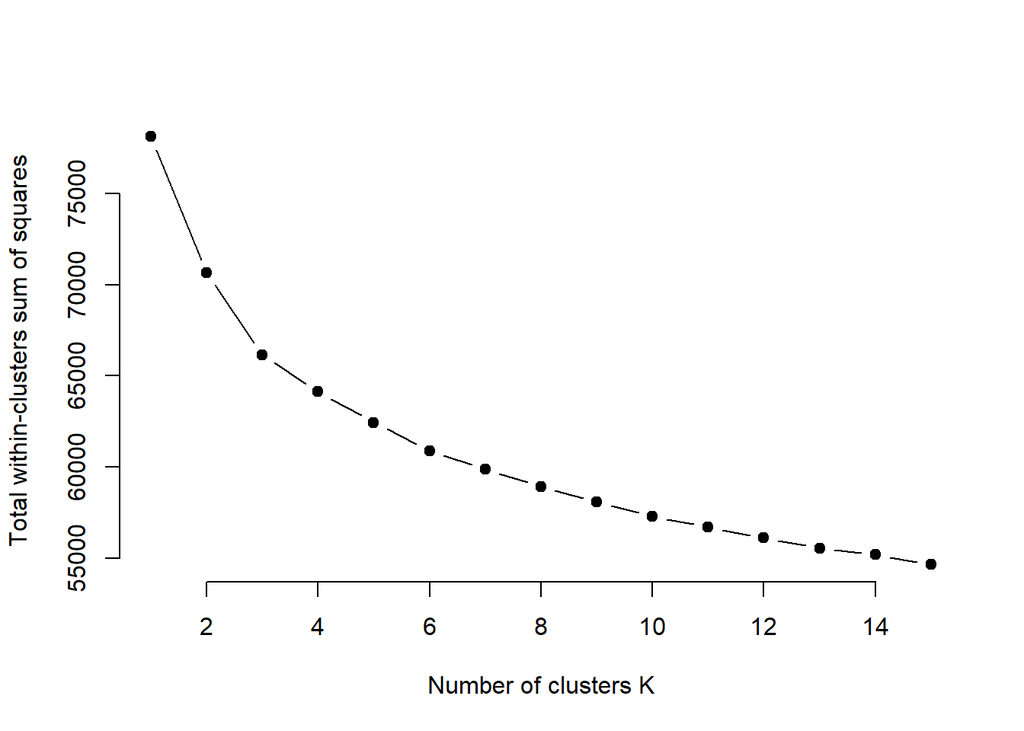

```r
#copy to new dataframe
cpnumft <- numft

# scale data before clustering
cpnumfta <- scale(cpnumft)

# elbow plot to find optimal k, use set seed to start with a random number
set.seed(123)

# function to compute total within-cluster sum of square
wss <- function(k) {
  kmeans(cpnumfta, k, nstart = 10 )$tot.withinss
}

# Compute and plot wss for k = 1 to k = 15
k.values <- 1:15

# extract wss for 2-15 clusters
wss_values <- map_dbl(k.values, wss)
plot(k.values, wss_values,
     type="b", pch = 19, frame = FALSE,
     xlab="Number of clusters K",
     ylab="Total within-clusters sum of squares")
```

The elbow plot indicates that the optimal k size may fall within 3 to 6 clusters. Below are plots for 3-6 clusters.

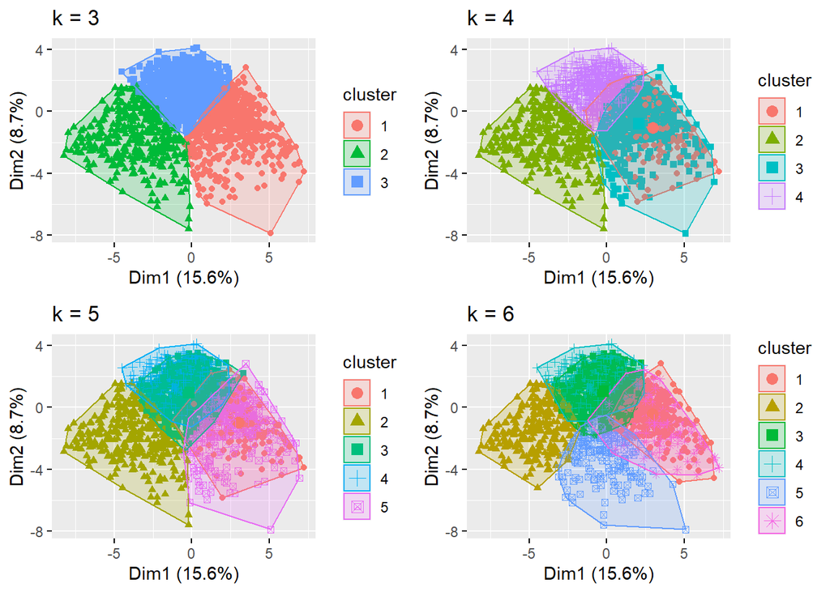

```r
# plot k= 3, 4,5,6,
seg.cptk3 <- kmeans(cpnumfta, centers=3, nstart = 25)
seg.cptk4 <- kmeans(cpnumfta, centers=4, nstart = 25)
seg.cptk5 <- kmeans(cpnumfta, centers=5, nstart = 25)
seg.cptk6 <- kmeans(cpnumfta, centers=6, nstart = 25)

# plots to compare
p1 <- fviz_cluster(seg.cptk3, geom = "point", data = cpnumfta) + ggtitle("k = 3")
p2 <- fviz_cluster(seg.cptk4, geom = "point",  data = cpnumfta) + ggtitle("k = 4")
p3 <- fviz_cluster(seg.cptk5, geom = "point",  data = cpnumfta) + ggtitle("k = 5")
p4 <- fviz_cluster(seg.cptk6, geom = "point",  data = cpnumfta) + ggtitle("k = 6")

library(gridExtra)
grid.arrange(p1, p2, p3, p4, nrow = 2)
```

The plot of 3 clusters has no overlapping clusters, so the customer segmentation will move forward with 3 clusters.

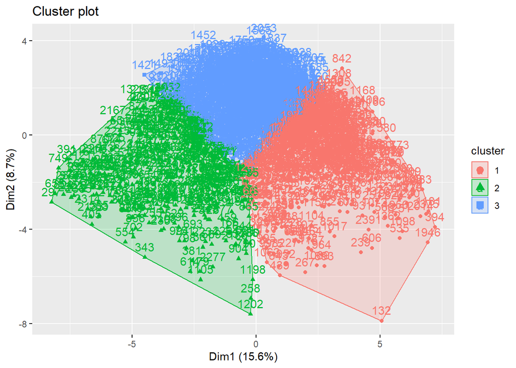

```r
#single fviz_cluster for k = 3
fviz_cluster(seg.cptk3, data = cpnumfta)
```

Further analysis on the mean response to the survey questions is needed to understand the customer profiles of each cluster.

```r
#Convert k = 3 to original scale, use original cpnumft dataframe and group by cluster
#to produce a table with the mean values of each cluster to allow for further
#analysis on each cluster.
cptk3con <- cpnumft %>%
  mutate(Cluster = seg.cptk3$cluster) %>%
  group_by(Cluster) %>%
  summarise_all("mean")

print(cptk3con, width = Inf) #print entire cluster and questions tibble
```

```
## # A tibble: 3 x 45
##   Cluster    q1  q2r1  q2r2  q2r3   q2r8  q4r1   q4r2  q4r3  q4r4  q4r5  q4r6
##     <int> <dbl> <dbl> <dbl> <dbl>  <dbl> <dbl>  <dbl> <dbl> <dbl> <dbl> <dbl>
## 1       1  4.82 0.374 0.145 0.369 0.0787 0.535 0.0490 0.240 0.103 0.610 0.642
## 2       2  3.72 0.524 0.444 0.462 0.376  0.769 0.521  0.721 0.644 0.855 0.812
## 3       3  4.70 0.581 0.213 0.336 0.188  0.808 0.140  0.489 0.193 0.829 0.939
##    q4r7  q4r8  q4r9  q4r10   q12 q13r1 q13r2 q13r3 q13r4 q13r5 q13r6 q13r7 q13r8
##   <dbl> <dbl> <dbl>  <dbl> <dbl> <dbl> <dbl> <dbl> <dbl> <dbl> <dbl> <dbl> <dbl>
## 1 0.360 0.219 0.152 0.0804  4.55  1.83  3.30  3.54  2.92  3.62  2.01  3.68  3.70
## 2 0.712 0.681 0.570 0.0456  3.55  1.19  1.69  2.17  1.75  2.09  1.25  2.20  2.13
## 3 0.572 0.555 0.403 0.0914  4.30  1.18  2.77  3.68  2.40  3.49  1.52  3.77  3.65
##   q13r9 q13r10 q13r11 q13r12 q24r1 q24r2 q24r3 q24r4 q24r5 q24r6 q24r7 q24r8
##   <dbl>  <dbl>  <dbl>  <dbl> <dbl> <dbl> <dbl> <dbl> <dbl> <dbl> <dbl> <dbl>
## 1  3.14   3.27   3.52   3.01  3.45  2.25  3.10  3.07  3.55  2.40  2.91  2.73
## 2  1.70   1.95   2.19   1.64  2.30  1.63  1.80  2.53  1.99  1.72  1.81  1.83
## 3  3.16   2.66   3.22   2.46  3.34  1.35  1.78  3.66  2.87  1.42  1.59  1.55
##   q24r9 q24r10 q24r11 q24r12 q26r12 q50r1   q56  q2ot
##   <dbl>  <dbl>  <dbl>  <dbl>  <dbl> <dbl> <dbl> <dbl>
## 1  3.55   2.89   3.40   2.80   3.82 0.474  7.52 0.337
## 2  2.98   1.74   1.91   1.74   2.07 0.530  7.77 0.538
## 3  4.35   1.63   2.02   1.54   3.09 0.521  8.19 0.210
```

Since the fviz_cluster function includes running Principle Components Analysis, it’s good to understand which variables contribute to the explained variances.

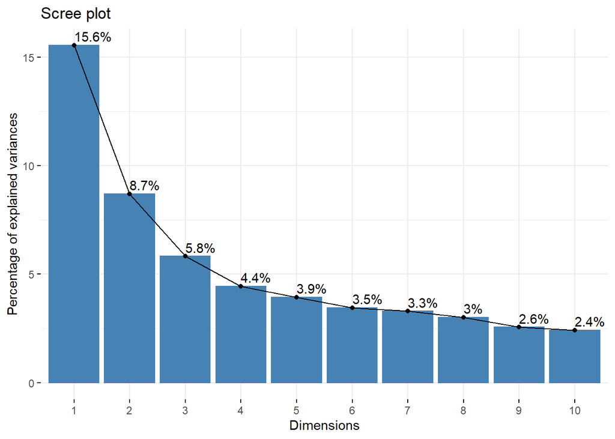

```r
#Run PCA on cpnumfta to see the variables that contribute to dim1 & dim2
P <- prcomp(cpnumfta, scale = FALSE)   #prcomp is pca function
fviz_eig(P, addlabels = TRUE)  #visualize the top dimensions
```

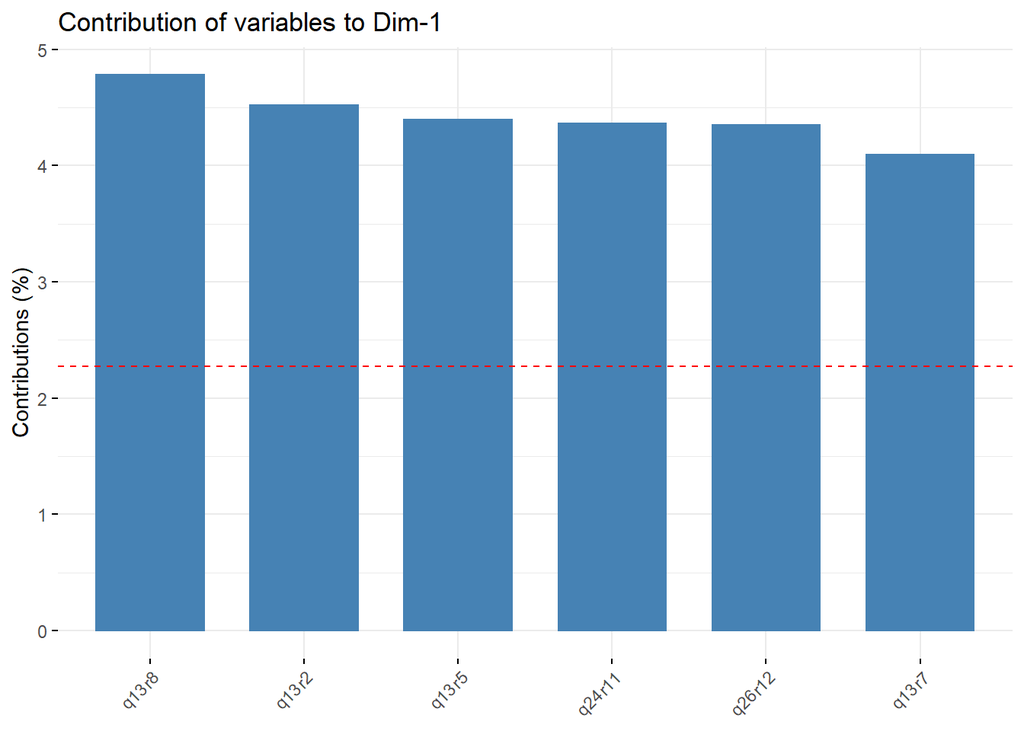

```r
#Dimensions 1 & 2 combined explain 24.3% of the variances

fviz_contrib(P, choice = "var", axes = 1, top = 6) # Top 6 contributors to the first component
```

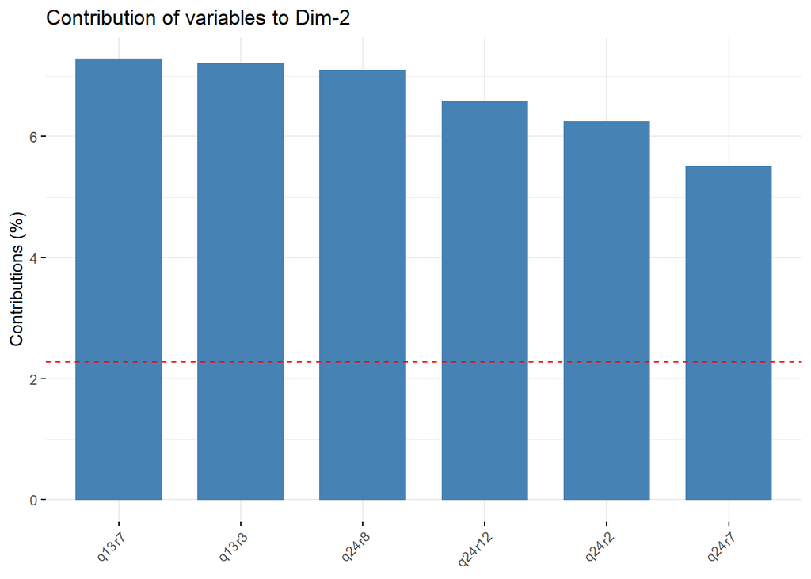

```r
fviz_contrib(P, choice = "var", axes = 2, top = 6)# Top 6 contributors to the 2nd component
```

Interpreting PCA and variables contributing to Dim1 & Dim2 #use FactoMineR package

```r
#use FactoMineR package
#Create dataframe to review contributions of variables to Principle Components in Dim1 & Dim2

res.pca <- PCA(cpnumfta,graph = FALSE)
var <- get_pca_var(res.pca)
var_cont <- var$contrib

var_cont1 <- as.data.frame(var_cont)

print(var_cont1)
```

```
##             Dim.1       Dim.2        Dim.3      Dim.4        Dim.5
## q1     0.73095533 0.856463259 9.501569e+00 8.76866504 7.761711e+00
## q2r1   0.39373432 1.080393316 1.160079e+01 1.24656332 6.702783e+00
## q2r2   1.43038754 0.262310090 1.214872e+00 0.92617011 7.439723e-01
## q2r3   0.04003933 0.020425207 5.693474e+00 1.16268961 1.502591e+00
## q2r8   1.65797796 0.024294840 5.069537e+00 0.44493528 1.477221e-01
## q4r1   0.97679947 1.415023163 2.408320e+00 8.81575201 2.613644e+00
## q4r2   3.52886120 0.741946647 1.642877e+00 0.70567592 2.941624e-01
## q4r3   2.96332788 0.002421435 5.909851e-01 3.85705327 1.124036e-01
## q4r4   3.58281570 1.133986279 1.085765e+00 0.80797193 3.926315e-01
## q4r5   1.07482223 0.927328918 2.978940e-01 5.79125625 9.268350e-02
## q4r6   0.86337930 4.742092258 1.068218e+00 5.99162439 5.810223e+00
## q4r7   1.74368923 0.286087085 4.031149e+00 0.21076075 3.459522e+00
## q4r8   2.41100326 0.644871376 3.532515e+00 0.90819385 7.092184e-01
## q4r9   2.09881808 0.269079418 6.956203e+00 1.15179149 1.203341e+00
## q4r10  0.04513118 0.101362416 4.487703e-01 0.15315871 7.677605e-04
## q12    1.27024177 0.688773642 2.810245e+00 0.60993910 2.012957e+00
## q13r1  1.54319453 1.612224536 7.282504e+00 1.79277838 6.779826e+00
## q13r2  4.51775886 0.856147338 1.419800e-01 0.03892476 7.911395e-01
## q13r3  3.59437139 7.211015812 4.476065e-01 1.24765438 1.175038e+00
## q13r4  2.73494387 0.013385787 7.854429e-03 2.84819515 6.681413e-04
## q13r5  4.39277949 4.706044606 3.606188e-01 0.95701199 3.264615e-01
## q13r6  2.94028170 0.000645717 1.943851e+00 1.22176546 9.781989e-02
## q13r7  4.09252704 7.278110843 1.642063e-05 0.82579727 7.013760e-01
## q13r8  4.78004909 5.108631496 8.991534e-02 0.05162406 2.616213e-02
## q13r9  3.09574809 4.317298380 1.282623e-01 2.51435278 2.289911e+00
## q13r10 3.62840839 0.127376218 1.196126e-01 2.29859751 4.803364e-02
## q13r11 3.47692336 1.295548396 3.024158e+00 0.28949508 2.023141e+00
## q13r12 3.12347180 0.194833152 1.798010e-01 1.87823966 1.406938e-01
## q24r1  1.14118396 0.776816384 1.509261e+00 2.94962870 3.160686e+00
## q24r2  1.52064480 6.242214529 1.502325e+00 3.24456627 4.365274e-01
## q24r3  2.71387597 2.356156062 8.181068e+00 0.02988679 3.401564e+00
## q24r4  0.12203516 3.266937341 3.889678e-02 1.95452219 1.218660e+01
## q24r5  3.53120256 0.048322870 2.242919e+00 1.82375447 6.682500e-01
## q24r6  1.69880313 4.926578776 4.925329e-01 0.74769561 3.171466e+00
## q24r7  3.69324551 5.503761008 1.309663e-02 2.52661581 8.622483e-01
## q24r8  2.53616915 7.094998866 2.008066e-01 3.59918470 4.713401e-01
## q24r9  0.09434322 5.162564533 5.721269e-02 1.99843712 6.461178e+00
## q24r10 3.63705163 5.266765306 5.122736e-02 3.81486008 7.856622e-01
## q24r11 4.36186445 3.161905204 1.249541e-01 1.72272560 1.777211e+00
## q24r12 3.46790371 6.584655857 2.279146e-02 3.08628256 6.383330e-01
## q26r12 4.34982968 0.079335158 3.096264e-01 2.42415265 1.798514e+00
## q50r1  0.03070987 0.003814777 1.948048e+00 8.08786106 8.647267e+00
## q56    0.02145865 0.941739157 1.124671e+01 1.33325646 1.345533e+00
## q2ot   0.34723715 2.665312541 3.791582e-01 3.13993240 6.227017e+00
```

#### Customer Profiles from the 3 Clusters

Distinct customer profiles can be derived by analyzing the mean values from the variables with the highest contributions to Dim1 & Dim2. The variables with the highest contributions included:  
* The frequency of using social media sites like Twitter (q13r2), MySpace (q13r3)  
* Usage of music sites like AOL Radio (q13r7), Last.fm (q13r8), and Vevo (q13r5 )  
* Entertainment interests: “I like learning more about my favorite TV shows when I’m not watching them (q24r8) and”Music is an important part of my life (q24r7)  
* “It’s usually worth spending a few extra dollars to get extra app features” (q26r12)  
* “People often ask my advice when they are looking to buy technology or electronic products” (q24r2)

The three customer segments derived were:  
* Low Engagers  
* Social Entertainers  
* Social Observers

All three segments exhibited high usage of Facebook, so usage of other social media sites in addition to Facebook was a key differentiator between the segments.

*Low Engagers* had low usage of other social media sites as well as low usage of music sites. While they had a medium level of interest in music, they had a low interest in paying for apps features.

*Social Entertainers* had higher usage of Twitter and MySpace than Social Observers as well asl higher usage of music sites. This segment also had a high interest in paying for app features.

*Social Observers* were differentiated in their higher usage of other social media sites but low usage of music sites. They did have a high interest in music, indicating that they may be potentially interested in a new music app.

From the higher usage of social media and music sites and the highest interest in paying for app features, the Social Entertainers segment has the highest potential to be interested in the social entertainment app. The Social Observers segment also shows potential interest, but may be more casual users. The Low Engagers have low potential to be interested in the app and should not be pursued.